# Práctica 1

Análisis de componentes principales

Jonás Jiménez Gil (Universidad Complutense de Madrid)  
2022-10-19

## Paquetes necesarios

Necesitaremos los siguientes paquetes:

```r
# Borramos variables del environment
rm(list = ls())
library(readxl)
library(skimr)
library(corrr)
library(corrplot)
library(tidyverse)
library(tidymodels)
library(factoextra)
library(FactoMineR)
```

# Carga de datos

El archivo de datos a usar será `distritos.xlsx`

```r
distritos <- read_xlsx(path = "./distritos.xlsx")
```

El fichero contiene **información socioeconómica de los distritos de Madrid**

```r
glimpse(distritos)
```

```
Rows: 21
Columns: 25
$ Distrito        <chr> "CENTRO", "ARGANZUELA", "RETIRO", "SALAMANCA…
$ Superficie      <dbl> 522.82, 646.22, 546.62, 539.24, 917.55, 537.…
$ Densidad        <dbl> 268.68, 240.88, 220.27, 274.19, 160.81, 300.…
$ Pob_0_14        <dbl> 0.07040617, 0.11254129, 0.11331576, 0.103008…
$ Pob_15_29       <dbl> 0.1737976, 0.1490916, 0.1412689, 0.1682110, …
$ Pob_30_44       <dbl> 0.3158491, 0.2427674, 0.2042706, 0.2215154, …
$ Pob_45_64       <dbl> 0.2838425, 0.2963830, 0.2780623, 0.2682267, …
$ `Pob_65+`       <dbl> 0.1561046, 0.1992167, 0.2630823, 0.2390381, …
$ N_Española      <dbl> 0.7490302, 0.8987044, 0.9254022, 0.8623617, …
$ Extranjeros     <dbl> 0.23997240, 0.10559900, 0.08563128, 0.145731…
$ `N_ hogares`    <dbl> 0.05290812, 0.05021863, 0.03758712, 0.048541…
$ Renta           <dbl> 0.8327653, 1.0470954, 1.3213335, 1.4359995, …
$ T_paro          <dbl> 9.66, 8.23, 6.86, 6.44, 6.45, 9.56, 6.73, 7.…
$ T_paro_H        <dbl> 9.75, 8.68, 7.22, 6.83, 6.80, 10.06, 7.09, 8…
$ `T- paro_M`     <dbl> 9.59, 7.75, 6.45, 5.98, 6.04, 8.99, 6.32, 6.…
$ Paro_LD         <dbl> 0.4436660, 0.4732050, 0.4869652, 0.4827642, …
$ Analfabetos     <dbl> 0.02737835, 0.02366100, 0.01792126, 0.014715…
$ `Primaria_ inc` <dbl> 0.07177252, 0.07756575, 0.05806819, 0.047803…
$ ESO             <dbl> 0.1828661, 0.1932008, 0.1541932, 0.1400314, …
$ fp_bach         <dbl> 0.1823671, 0.1940346, 0.1911015, 0.1809926, …
$ T_medios        <dbl> 0.09434386, 0.11998877, 0.12099953, 0.104595…
$ T_superiores    <dbl> 0.4405652, 0.3903865, 0.4563919, 0.5105107, …
$ S_M2_vivienda   <dbl> 0.9382243, 0.8265654, 1.1252891, 1.1600919, …
$ Valor_V         <dbl> 1.2802470, 0.9256645, 1.4522995, 1.7496416, …
$ Partido         <chr> "Más Madrid", "Más Madrid", "PP", "PP", "PP"…
```

Las variables recopilan la siguiente información:

- `Superficie`: superficie del distrito (hectáreas)
- `Densidad`: densidad de población
- `Pob_0_14`: proporción de población menor de 14 años
- `Pob_15_29`: proporción de población de 15 a 29
- `Pob_30_44`: proporción de población de 30 a 44
- `Pob_45_64`: proporción de población de 45 a 64
- `Pob_65+`: proporción de población de 65 o mas
- `N_Española`: proporción de población española
- `Extranjeros`: proporción de población extranjera
- `N_ hogares`: número de hogares en miles
- `Renta`: renta media en miles
- `T_paro`: porcentaje de población parada
- `T_paro_H`: porcentaje de hombres parados
- `T_ paro_M`: porcentaje de mujeres paradas
- `Paro_LD`: proporción de población parada de larga duración
- `Analfabetos`: proporción de población que no sabe leer ni escribir
- `Primaria_ inc`: proporción de población solo con estudios primarios
- `ESO`: proporción de población solo ESO
- `fp_bach`: proporción de población solo con FP o Bachillerato
- `T_medios`: proporción de población Titulada media
- `T_superiores`: proporción de población con estudios superiores
- `S_M2_vivienda`: superficie media de la vivienda
- `Valor_V`: valor catastral medio de la vivienda
- `Partido`: partido más votado en las municipales 2019

# Ejercicio 1:

> Calcula los estadísticos básicos de todas las variables con la función `skim()` del paquete `{skimr}`

```r
# Utilizamos la función skim para obtener los estadísticos básicos
distritos %>% skim()
```

Table 1: Data summary

| Name | Piped data |
| --- | --- |
| Number of rows | 21 |
| Number of columns | 25 |
| _______________________ |  |
| Column type frequency: |  |
| character | 2 |
| numeric | 23 |
| ________________________ |  |
| Group variables | None |

**Variable type: character**

| skim_variable | n_missing | complete_rate | min | max | empty | n_unique | whitespace |
| --- | --- | --- | --- | --- | --- | --- | --- |
| Distrito | 0 | 1 | 5 | 19 | 0 | 21 | 0 |
| Partido | 0 | 1 | 2 | 10 | 0 | 2 | 0 |

**Variable type: numeric**

| skim_variable | n_missing | complete_rate | mean | sd | p0 | p25 | p50 | p75 | p100 | hist |
| --- | --- | --- | --- | --- | --- | --- | --- | --- | --- | --- |
| Superficie | 0 | 1 | 2878.36 | 5009.97 | 467.92 | 610.32 | 1404.83 | 2741.98 | 23783.84 | ▇▁▁▁▁ |
| Densidad | 0 | 1 | 145.30 | 99.91 | 10.51 | 70.48 | 160.81 | 220.27 | 301.05 | ▇▆▆▆▆ |
| Pob_0_14 | 0 | 1 | 0.13 | 0.03 | 0.07 | 0.11 | 0.13 | 0.15 | 0.18 | ▁▇▅▂▅ |
| Pob_15_29 | 0 | 1 | 0.16 | 0.01 | 0.14 | 0.15 | 0.17 | 0.17 | 0.18 | ▅▃▃▅▇ |
| Pob_30_44 | 0 | 1 | 0.22 | 0.03 | 0.17 | 0.21 | 0.22 | 0.22 | 0.32 | ▂▇▁▁▁ |
| Pob_45_64 | 0 | 1 | 0.29 | 0.02 | 0.26 | 0.27 | 0.29 | 0.30 | 0.33 | ▇▆▇▁▂ |
| Pob_65+ | 0 | 1 | 0.20 | 0.04 | 0.13 | 0.17 | 0.19 | 0.24 | 0.26 | ▂▇▅▅▇ |
| N_Española | 0 | 1 | 0.85 | 0.05 | 0.75 | 0.81 | 0.86 | 0.89 | 0.93 | ▃▃▃▇▇ |
| Extranjeros | 0 | 1 | 0.15 | 0.05 | 0.09 | 0.11 | 0.13 | 0.20 | 0.24 | ▇▅▂▂▃ |
| N_ hogares | 0 | 1 | 0.05 | 0.02 | 0.01 | 0.04 | 0.05 | 0.05 | 0.07 | ▂▅▇▅▇ |
| Renta | 0 | 1 | 1.02 | 0.30 | 0.64 | 0.78 | 0.90 | 1.25 | 1.64 | ▇▃▃▃▂ |
| T_paro | 0 | 1 | 9.60 | 2.45 | 6.44 | 7.41 | 9.66 | 11.28 | 13.90 | ▇▂▇▃▃ |
| T_paro_H | 0 | 1 | 10.31 | 2.73 | 6.80 | 8.10 | 10.06 | 12.12 | 15.37 | ▇▅▅▃▃ |
| T- paro_M | 0 | 1 | 8.82 | 2.20 | 5.98 | 6.66 | 9.14 | 9.82 | 12.97 | ▇▁▇▂▃ |
| Paro_LD | 0 | 1 | 0.51 | 0.03 | 0.44 | 0.49 | 0.50 | 0.52 | 0.57 | ▂▅▇▁▂ |
| Analfabetos | 0 | 1 | 0.04 | 0.02 | 0.01 | 0.02 | 0.04 | 0.06 | 0.10 | ▇▆▆▂▂ |
| Primaria_ inc | 0 | 1 | 0.11 | 0.04 | 0.04 | 0.07 | 0.10 | 0.13 | 0.18 | ▇▅▃▅▅ |
| ESO | 0 | 1 | 0.26 | 0.09 | 0.13 | 0.18 | 0.26 | 0.33 | 0.40 | ▇▅▃▅▅ |
| fp_bach | 0 | 1 | 0.19 | 0.02 | 0.17 | 0.18 | 0.19 | 0.21 | 0.23 | ▅▇▅▇▂ |
| T_medios | 0 | 1 | 0.10 | 0.02 | 0.05 | 0.09 | 0.10 | 0.11 | 0.13 | ▃▂▇▇▃ |
| T_superiores | 0 | 1 | 0.30 | 0.14 | 0.10 | 0.17 | 0.33 | 0.44 | 0.52 | ▇▂▅▂▇ |
| S_M2_vivienda | 0 | 1 | 1.00 | 0.25 | 0.74 | 0.81 | 0.94 | 1.13 | 1.77 | ▇▃▃▁▁ |
| Valor_V | 0 | 1 | 1.01 | 0.39 | 0.48 | 0.68 | 0.93 | 1.28 | 1.75 | ▇▆▃▃▃ |

# Ejercicio 2

## Ejercicio 2.1

> Calcula la matriz de covarianzas (guárdala en `cov_mat`). Recuerda que la matriz de covarianzas y de correlaciones solo puede ser calculada para variables numéricas.

```r
# Calculamos la matriz de covarianzas
cov_mat <-
  cov(distritos %>% select(-Distrito, -Partido))
cov_mat
```

```
                 Superficie      Densidad      Pob_0_14     Pob_15_29
Superficie     2.509980e+07 -2.723950e+05  7.090649e+01 -2.702233e+01
Densidad      -2.723950e+05  9.982157e+03 -2.267879e+00  3.214672e-01
Pob_0_14       7.090649e+01 -2.267879e+00  7.483554e-04 -1.150390e-04
Pob_15_29     -2.702233e+01  3.214672e-01 -1.150390e-04  1.725171e-04
Pob_30_44     -1.452846e+01  1.173452e+00 -2.070205e-04  3.530412e-05
Pob_45_64     -1.557111e+01 -6.262101e-01  9.464202e-05  7.828234e-05
Pob_65+       -1.378459e+01  1.399170e+00 -5.209380e-04 -1.710645e-04
N_Española     7.770851e+01 -1.276020e+00  3.002352e-04 -5.135034e-04
Extranjeros   -8.030125e+01  1.657900e+00 -4.023416e-04  4.838173e-04
N_ hogares     1.546320e+01  4.646118e-01 -1.215111e-04  8.788150e-06
Renta          2.490044e+02  1.381384e+00 -3.893231e-04 -1.944640e-03
T_paro        -2.129322e+03 -3.788309e+01  1.097707e-02  1.758659e-02
T_paro_H      -1.876252e+03 -6.057322e+01  1.899668e-02  1.830567e-02
T- paro_M     -2.389406e+03 -1.464603e+01  2.705493e-03  1.689791e-02
Paro_LD        2.580263e+01 -1.585318e+00  4.823888e-04  3.978210e-05
Analfabetos   -4.535936e+00 -8.362030e-01  2.319188e-04  1.554257e-04
Primaria_ inc -1.707713e+01 -1.074565e+00  2.688656e-04  2.874762e-04
ESO           -3.171868e+01 -2.590588e+00  8.126678e-04  5.684401e-04
fp_bach        3.602300e+00 -8.268281e-01  1.731187e-04 -8.192035e-05
T_medios       2.424108e+01 -1.777418e-01  3.891352e-05 -2.084740e-04
T_superiores   2.627871e+01  5.484254e+00 -1.518209e-03 -7.208357e-04
S_M2_vivienda  4.080862e+02 -7.757484e+00  1.163969e-03 -8.407712e-04
Valor_V       -7.506199e+01  1.201698e+01 -3.787795e-03 -1.498917e-03
                  Pob_30_44     Pob_45_64       Pob_65+    N_Española
Superficie    -1.452846e+01 -1.557111e+01 -1.378459e+01  7.770851e+01
Densidad       1.173452e+00 -6.262101e-01  1.399170e+00 -1.276020e+00
Pob_0_14      -2.070205e-04  9.464202e-05 -5.209380e-04  3.002352e-04
Pob_15_29      3.530412e-05  7.828234e-05 -1.710645e-04 -5.135034e-04
Pob_30_44      9.377136e-04 -1.988087e-04 -5.671886e-04 -7.786816e-04
Pob_45_64     -1.988087e-04  2.951157e-04 -2.692314e-04 -1.503788e-04
Pob_65+       -5.671886e-04 -2.692314e-04  1.528422e-03  1.142329e-03
N_Española    -7.786816e-04 -1.503788e-04  1.142329e-03  2.808682e-03
Extranjeros    6.958930e-04  8.047905e-05 -8.578478e-04 -2.607610e-03
N_ hogares     7.153798e-05 -8.141394e-05  1.225989e-04 -2.331576e-04
Renta         -1.681804e-03 -2.559607e-03  6.575374e-03  1.148747e-02
T_paro         2.817948e-03  2.060414e-02 -5.198575e-02 -9.379105e-02
T_paro_H       1.091395e-03  2.356694e-02 -6.196068e-02 -9.888442e-02
T- paro_M      4.918407e-03  1.767619e-02 -4.219800e-02 -8.886932e-02
Paro_LD       -3.158292e-04  1.986309e-04 -4.049726e-04  5.296012e-05
```

[output cut: 89 more lines]

```
Extranjeros   -0.0035505534 -7.069227e-03 -9.183735e-03
N_ hogares    -0.0001782975 -9.107446e-04 -9.485764e-04
Renta          0.0383597982  5.781781e-02  1.061917e-01
T_paro        -0.3338840087 -4.271971e-01 -8.584291e-01
T_paro_H      -0.3784766188 -4.592728e-01 -9.681808e-01
T- paro_M     -0.2880136949 -3.947475e-01 -7.465366e-01
Paro_LD       -0.0029167690 -1.263726e-03 -6.629849e-03
Analfabetos   -0.0033887031 -3.428432e-03 -8.473416e-03
Primaria_ inc -0.0061497654 -6.562892e-03 -1.553379e-02
ESO           -0.0127564559 -1.405404e-02 -3.257800e-02
fp_bach       -0.0009033758 -8.786936e-04 -2.369056e-03
T_medios       0.0021524385  2.766383e-03  5.117693e-03
T_superiores   0.0210093822  2.212663e-02  5.372689e-02
S_M2_vivienda  0.0221266282  6.176824e-02  6.739844e-02
Valor_V        0.0537268919  6.739844e-02  1.505134e-01
```

## Ejercicio 2.2

> Calcula la matriz de correlaciones, de forma numérica (guárdala en `cor_mat`) y gráfica, haciendo uso de los paquetes `{corrr}` y `{corrplot}`. Responde además a las preguntas: ¿cuáles son las variables más correlacionadas (linealmente)? ¿Cómo es el sentido de esa correlación?

```r
# Calculamos la matriz de correlaciones
cor_mat <-
  cor(distritos %>%  select(-Distrito, -Partido))
cor_mat
```

```
               Superficie    Densidad    Pob_0_14   Pob_15_29
Superficie     1.00000000 -0.54419146  0.51736479 -0.41064976
Densidad      -0.54419146  1.00000000 -0.82976222  0.24496746
Pob_0_14       0.51736479 -0.82976222  1.00000000 -0.32016585
Pob_15_29     -0.41064976  0.24496746 -0.32016585  1.00000000
Pob_30_44     -0.09469984  0.38354633 -0.24712931  0.08777569
Pob_45_64     -0.18092071 -0.36484775  0.20138814  0.34693777
Pob_65+       -0.07037802  0.35820907 -0.48709127 -0.33313654
N_Española     0.29267264 -0.24098711  0.20708867 -0.73769348
Extranjeros   -0.32184146  0.33319688 -0.29532201  0.73963966
N_ hogares     0.18506058  0.27882248 -0.26632492  0.04011725
Renta          0.16597203  0.04617057 -0.04752470 -0.49440900
T_paro        -0.17364595 -0.15491435  0.16394228  0.54704637
T_paro_H      -0.13720943 -0.22212444  0.25442021  0.51061965
T- paro_M     -0.21701655 -0.06670306  0.04500186  0.58540305
Paro_LD        0.16155859 -0.49774313  0.55315191  0.09501076
Analfabetos   -0.03705825 -0.34257268  0.34700454  0.48435087
Primaria_ inc -0.07748806 -0.24449808  0.22342737  0.49755482
ESO           -0.07082988 -0.29008332  0.33235000  0.48417824
fp_bach        0.04482890 -0.51596031  0.39455113 -0.38885626
T_medios       0.23547330 -0.08657693  0.06922633 -0.77243280
T_superiores   0.03618781  0.37870296 -0.38288735 -0.37862879
S_M2_vivienda  0.32774350 -0.31241083  0.17120043 -0.25756047
Valor_V       -0.03861868  0.31002425 -0.35689872 -0.29415353
                Pob_30_44   Pob_45_64     Pob_65+ N_Española
Superficie    -0.09469984 -0.18092071 -0.07037802  0.2926726
Densidad       0.38354633 -0.36484775  0.35820907 -0.2409871
Pob_0_14      -0.24712931  0.20138814 -0.48709127  0.2070887
Pob_15_29      0.08777569  0.34693777 -0.33313654 -0.7376935
Pob_30_44      1.00000000 -0.37792364 -0.47377338 -0.4798146
Pob_45_64     -0.37792364  1.00000000 -0.40087394 -0.1651730
Pob_65+       -0.47377338 -0.40087394  1.00000000  0.5513381
N_Española    -0.47981460 -0.16517299  0.55133807  1.0000000
Extranjeros    0.45631236  0.09406792 -0.44059887 -0.9879756
N_ hogares     0.14007198 -0.28415306  0.18802462 -0.2637837
Renta         -0.18340170 -0.49755396  0.56164496  0.7238296
T_paro         0.03759727  0.49002325 -0.54327665 -0.7230503
T_paro_H       0.01305795  0.50261431 -0.58066060 -0.6836038
T- paro_M      0.07308484  0.46819911 -0.49114327 -0.7630245
Paro_LD       -0.32353279  0.36270360 -0.32494145  0.0313472
```

[output cut: 89 more lines]

```
Extranjeros    -0.49186313    -0.5711421 -0.47532065
N_ hogares     -0.07375447    -0.2197170 -0.14660019
Renta           0.88375685     0.7768589  0.91404244
T_paro         -0.94112526    -0.7022700 -0.90401446
T_paro_H       -0.95666595    -0.6770426 -0.91431712
T- paro_M      -0.90415834    -0.7227278 -0.87559159
Paro_LD        -0.63124296    -0.1595040 -0.53606480
Analfabetos    -0.95692973    -0.5646327 -0.89397253
Primaria_ inc  -0.96451063    -0.6002992 -0.91021695
ESO            -0.98460025    -0.6326377 -0.93944950
fp_bach        -0.38857520    -0.2204287 -0.38071603
T_medios        0.72268477     0.5416946  0.64196526
T_superiores    1.00000000     0.6142229  0.95542710
S_M2_vivienda   0.61422285     1.0000000  0.69900405
Valor_V         0.95542710     0.6990040  1.00000000
```

```r
# La graficamos
corrplot(cor(distritos %>%  select(-Distrito, -Partido)), type = "upper",
         tl.col = "black",  method = "ellipse")

corrplot(cor_mat, method = 'number')
```

[output not shown]

# Ejercicio 3

> Haciendo uso de `{ggplot2}`, representa los gráficos de dispersión de las variables T_paro (eje y) con relación a Analfabetos (eje x), y T_paro en relación a T_superiores. Comentar el sentido de las nubes de puntos, junto con las correlaciones obtenidas anteriormente

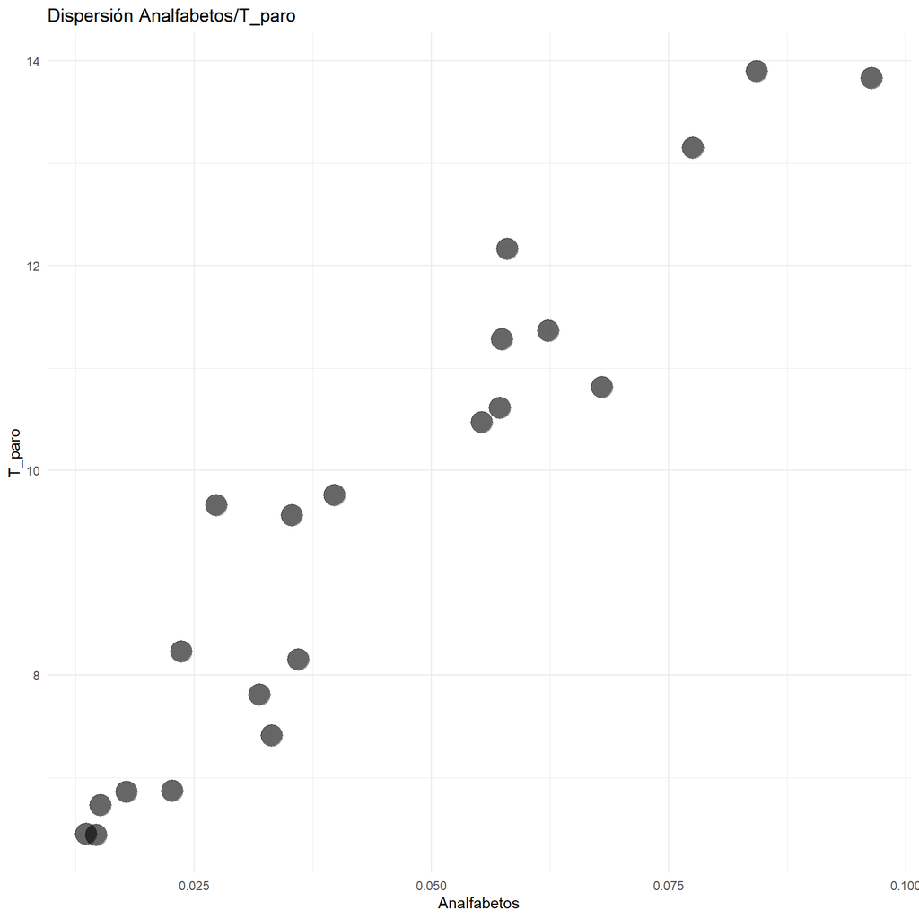

```r
# Generamos un ggplot para represntar los gráficos de dispersión
ggplot(distritos, aes(x = Analfabetos, y = T_paro)) +
  geom_point(size = 7, alpha = 0.6) +
  labs(x = "Analfabetos", y = "T_paro",
       title = "Dispersión Analfabetos/T_paro") +
  theme_minimal()
```

Observamos una correlación positiva alta entre Analfabetos y T_paro, ya que a mayor valor en la variable Analfabetos. mayor valor en la variable T_paro

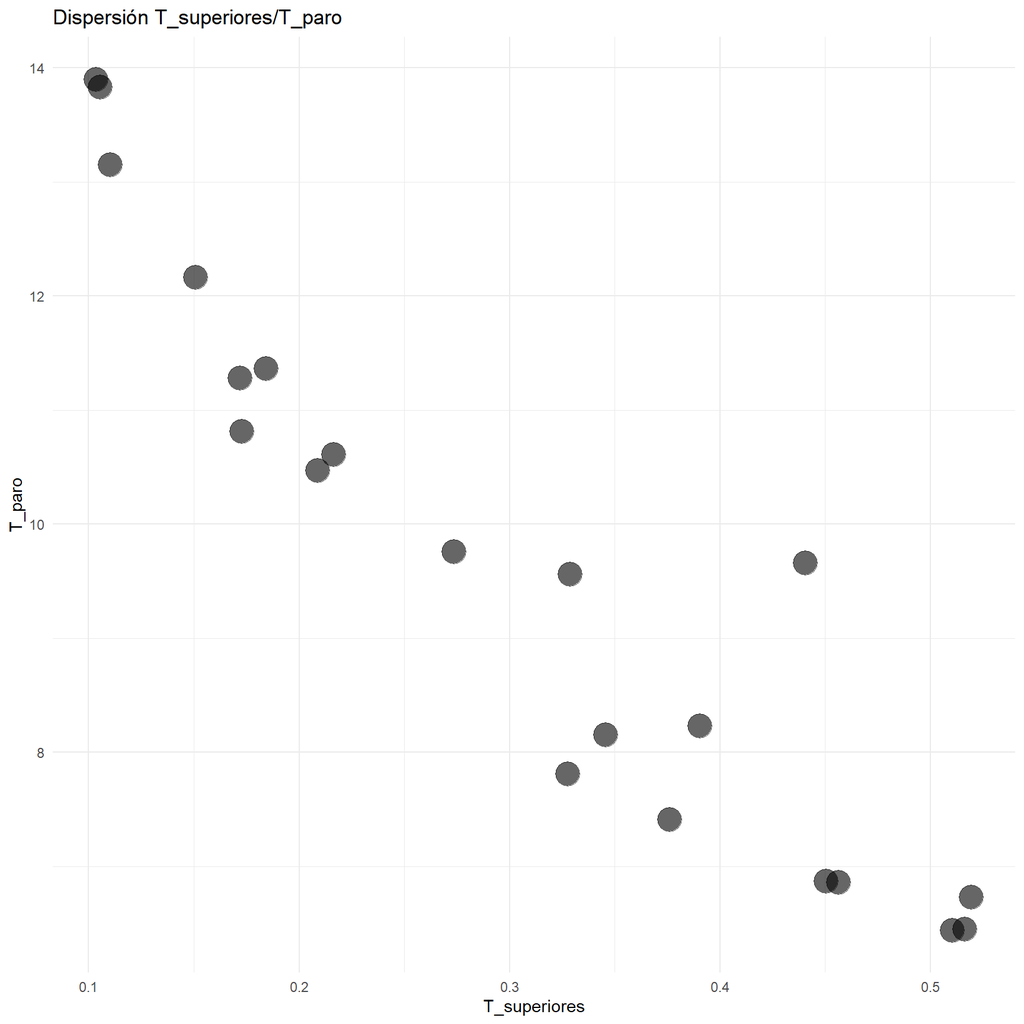

```r
# Generamos el segundo gráfico de dispersión
ggplot(distritos, aes(x = T_superiores, y = T_paro)) +
  geom_point(size = 7, alpha = 0.6) +
  labs(x = "T_superiores", y = "T_paro",
       title = "Dispersión T_superiores/T_paro") +
  theme_minimal()
```

En cambio en este caso observamos una correlación negativa alta entre T_superiores y T_paro, ya que el valor de T_superiores disminuye a medida que el valor de T_paro aumenta

# Ejercicio 4

## Ejercicio 4.1

> Haciendo uso de los paquetes `{FactoMineR}` y `{factoextra}`, realiza un análisis de componentes principales y guárdalo en el objeto `pca_fit`

```r
# Analizamos los componentes principales
pca_fit <-
  PCA(distritos %>%  select(-Distrito, -Partido), scale.unit = TRUE , ncp = ncol(distritos), graph = FALSE)
```

> Obtén los autovalores asociados y detalla los resultados. ¿Cuánto explica la primera componente? ¿Cuánto explican las primeras 10 componentes?

```r
# Obtenemos los autovalores asociados
pca_fit$eig
```

```
          eigenvalue percentage of variance
comp 1  1.198707e+01           5.211769e+01
comp 2  4.416569e+00           1.920248e+01
comp 3  1.708242e+00           7.427140e+00
comp 4  1.525375e+00           6.632064e+00
comp 5  1.364948e+00           5.934558e+00
comp 6  6.881371e-01           2.991900e+00
comp 7  3.734209e-01           1.623569e+00
comp 8  2.897219e-01           1.259661e+00
comp 9  2.723608e-01           1.184177e+00
comp 10 1.448573e-01           6.298142e-01
comp 11 9.231192e-02           4.013562e-01
comp 12 7.461633e-02           3.244188e-01
comp 13 2.768712e-02           1.203788e-01
comp 14 1.274897e-02           5.543032e-02
comp 15 1.236283e-02           5.375145e-02
comp 16 5.703179e-03           2.479643e-02
comp 17 2.399131e-03           1.043100e-02
comp 18 7.689520e-04           3.343270e-03
comp 19 5.940363e-04           2.582767e-03
comp 20 1.070665e-04           4.655067e-04
        cumulative percentage of variance
comp 1                           52.11769
comp 2                           71.32016
comp 3                           78.74730
comp 4                           85.37937
comp 5                           91.31392
comp 6                           94.30582
comp 7                           95.92939
comp 8                           97.18905
comp 9                           98.37323
comp 10                          99.00305
comp 11                          99.40440
comp 12                          99.72882
comp 13                          99.84920
comp 14                          99.90463
comp 15                          99.95838
comp 16                          99.98318
comp 17                          99.99361
comp 18                          99.99695
comp 19                          99.99953
comp 20                         100.00000
```

> Obtén los autovectores por columnas y la contribución de cada variable original a la varianza explicada de cada componente.

```r
# Obtenemos los autovectores por columnas
pca_fit$svd$V
```

```
              [,1]        [,2]         [,3]         [,4]         [,5]
 [1,] -0.044996564  0.23465060  0.456302477  0.352123379 -0.014476955
 [2,] -0.050170983 -0.41402574 -0.182077268 -0.015918841 -0.169487301
 [3,]  0.055530972  0.39016851  0.306165578 -0.004710738  0.111056329
 [4,]  0.167396487 -0.23231478 -0.128784859 -0.058004327  0.477123964
 [5,]  0.009221178 -0.26339675  0.494825233 -0.344163934 -0.175975821
 [6,]  0.155760985  0.17710005 -0.317187535 -0.260012233  0.124660104
 [7,] -0.170762591 -0.06647268 -0.419173508  0.406611333 -0.154947089
 [8,] -0.211760742  0.26706730 -0.180814523  0.103607494 -0.106003198
 [9,]  0.204597946 -0.30159006  0.138422526 -0.032640620  0.070923329
[10,]  0.040589364 -0.18881760  0.170431585  0.556257709 -0.288138696
[11,] -0.273128453  0.03941863 -0.013477934  0.077068153  0.181427645
[12,]  0.286512091 -0.00946142 -0.009549039  0.024920808 -0.026849358
[13,]  0.285762218  0.02847863  0.009670192  0.009705899 -0.010694697
[14,]  0.282631644 -0.05825777 -0.031678065  0.039365938 -0.046282060
```

[output cut: 105 more lines]

```r
# Obtenemos la contribución
pca_fit$var$contrib
```

```
                    Dim.1        Dim.2        Dim.3        Dim.4
Superficie    0.202469080  5.506090573 20.821195080 12.399087391
Densidad      0.251712749 17.141730945  3.315213137  0.025340950
Pob_0_14      0.308368885 15.223146338  9.373736139  0.002219105
Pob_15_29     2.802158379  5.397015618  1.658554001  0.336450193
Pob_30_44     0.008503012  6.937784841 24.485201127 11.844881325
Pob_45_64     2.426148439  3.136442937 10.060793236  6.760636157
Pob_65+       2.915986237  0.441861771 17.570642944 16.533277619
N_Española    4.484261173  7.132494237  3.269389161  1.073451286
Extranjeros   4.186031954  9.095656283  1.916079566  0.106541009
N_ hogares    0.164749646  3.565208757  2.904692522 30.942263869
Renta         7.459915187  0.155382830  0.018165469  0.593950024
T_paro        8.208917805  0.008951846  0.009118415  0.062104667
T_paro_H      8.166004503  0.081103220  0.009351260  0.009420447
T- paro_M     7.988064608  0.339396761  0.100349983  0.154967709
Paro_LD       2.233643252  7.578678445  0.199541037  1.030807254
Analfabetos   7.594498118  0.903156372  0.060526570  0.711530454
Primaria_ inc 7.628475597  0.236155056  0.768721028  2.966679689
ESO           7.970993166  0.511108774  0.013835559  0.502695362
fp_bach       0.268900482  9.650817932  2.226410730  8.330824746
T_medios      6.153596379  2.336063612  0.112842019  4.465666680
T_superiores  7.533955944  1.695554332  0.257954336  0.245434650
S_M2_vivienda 3.989571547  1.700623407  0.732128065  0.857219230
Valor_V       7.053073857  1.225575113  0.115558615  0.044550184
                     Dim.5        Dim.6        Dim.7        Dim.8
Superficie    2.095822e-02  5.138441238 11.601431226 3.299448e+01
Densidad      2.872595e+00  5.332975482  7.559719803 2.985679e-01
Pob_0_14      1.233351e+00  1.546619514  6.795364235 2.098087e+00
Pob_15_29     2.276473e+01  1.659236856  3.273555374 1.515561e-01
Pob_30_44     3.096749e+00  2.280061038  2.634164570 1.442979e+00
Pob_45_64     1.554014e+00 24.960382715 20.230502284 1.275215e+00
Pob_65+       2.400860e+00  0.330797679  4.126902116 5.381778e+00
N_Española    1.123668e+00  2.664501713  5.032153752 1.211573e-01
Extranjeros   5.030119e-01  1.600023010  6.002188057 3.747943e-01
N_ hogares    8.302391e+00  9.460873369  2.344611114 3.843177e+01
Renta         3.291599e+00  0.260249010  2.483658072 1.416796e+00
T_paro        7.208880e-02  0.281365560  0.570138818 2.495927e-02
T_paro_H      1.143765e-02  0.893805905  0.722386842 4.209607e-03
T- paro_M     2.142029e-01  0.002043419  0.328748179 9.326281e-02
Paro_LD       1.757451e+00 33.049949213 15.874890321 6.888225e+00
```

[output cut: 65 more lines]

```
Extranjeros    1.311231451  6.26070779  4.144200014 3.971773e+01
N_ hogares     0.079193096  0.96728007  0.004673404 1.917552e-01
Renta          1.375760500  2.21144467 19.036626441 1.593301e+00
T_paro         1.345236438  2.53522957  0.059039370 6.078495e-01
T_paro_H       7.489162758  4.07790177 15.629883574 6.666956e+00
T- paro_M      1.194454401  1.08747422 23.483904336 8.736960e+00
Paro_LD        0.001818723  0.94069688  0.226317043 9.723033e-01
Analfabetos    2.727556538  0.05825458  5.746252015 2.087535e+00
Primaria_ inc 23.253274113  0.03870488  1.041869649 6.140704e+00
ESO           38.471887040  1.81963742  5.331024739 5.055717e+00
fp_bach        2.723993123  5.56450575  0.127681380 1.555321e+00
T_medios       2.829051863 42.01350772  1.063341785 5.132760e+00
T_superiores   7.450562226  0.05918171  3.140905296 1.604669e+00
S_M2_vivienda  0.074830308  3.75956398  1.145433780 2.009786e-01
Valor_V        6.284362045  5.23075415  4.599768395 3.909654e+00
```

> Obtén los scores (las nuevas coordenadas de los datos, s proyectados en las nuevas direcciones).

```r
# Obtenemos los scores
pca_scores <- as_tibble(pca_fit$ind$coord)
names(pca_scores) <- c("PC_1", "PC_2", "PC_3", "PC_4", "PC_5", "PC_6", "PC_7", "PC_8", "PC_9", "PC_10", "PC_11", "PC_12", "PC_13", "PC_14", "PC_15", "PC_16", "PC_17", "PC_18", "PC_19", "PC_20")
pca_scores # Nuevas coordenadas
```

```
# A tibble: 21 × 20
     PC_1   PC_2    PC_3   PC_4   PC_5   PC_6   PC_7   PC_8    PC_9
    <dbl>  <dbl>   <dbl>  <dbl>  <dbl>  <dbl>  <dbl>  <dbl>   <dbl>
 1 -0.131 -4.89   1.81   -2.17  -0.180  1.17   0.342 -0.149  0.890
 2 -2.04  -0.516 -0.380  -1.02  -1.71   0.367  0.951  0.103 -1.01
 3 -4.59   0.165 -1.39    0.106 -0.770 -0.586 -0.193 -0.253 -0.312
 4 -4.33  -2.23  -0.529   0.157  0.810 -0.335 -0.108  0.102  0.282
 5 -4.97  -0.248 -0.196   0.333  0.545 -0.894 -0.293  0.477 -0.360
 6  0.532 -2.83   0.603  -0.424 -0.338 -0.855  0.347 -0.147  0.175
 7 -4.19  -2.71  -0.314   0.486  0.368 -0.884  0.213 -0.400 -0.463
 8 -3.01   2.87   3.10    2.92  -0.467  0.666  0.813 -0.923  0.0649
 9 -3.96   0.796 -0.0517  0.514  3.21   0.740 -0.469  0.187  0.650
10  2.29  -0.186 -0.693   1.69  -1.73   0.651 -0.809  0.129  0.590
# … with 11 more rows, and 11 more variables: PC_10 <dbl>,
#   PC_11 <dbl>, PC_12 <dbl>, PC_13 <dbl>, PC_14 <dbl>, PC_15 <dbl>,
#   PC_16 <dbl>, PC_17 <dbl>, PC_18 <dbl>, PC_19 <dbl>, PC_20 <dbl>
```

## Ejercicio 4.2

> Determina el número de componentes para explicar al menos el 95% de varianza. Realiza el mismo análisis del ejercicio 4.1 pero solo seleccionando dichas componentes. ¿Qué grupos de variables contribuyen más a cada componente?

```r
# Las 7 primeras variables explican al menos el 95% de la varianza
pca_fit <-
  PCA(distritos %>%  select(-Distrito, -Partido), scale.unit = TRUE, ncp = 7, graph = FALSE)

# ¿Qué grupos de variables contribuyen más a cada componente?
# La siguiente tabla responde a esta pregunta
round(pca_fit$var$cos2,3)
```

```
              Dim.1 Dim.2 Dim.3 Dim.4 Dim.5 Dim.6 Dim.7
Superficie    0.024 0.243 0.356 0.189 0.000 0.035 0.043
Densidad      0.030 0.757 0.057 0.000 0.039 0.037 0.028
Pob_0_14      0.037 0.672 0.160 0.000 0.017 0.011 0.025
Pob_15_29     0.336 0.238 0.028 0.005 0.311 0.011 0.012
Pob_30_44     0.001 0.306 0.418 0.181 0.042 0.016 0.010
Pob_45_64     0.291 0.139 0.172 0.103 0.021 0.172 0.076
Pob_65+       0.350 0.020 0.300 0.252 0.033 0.002 0.015
N_Española    0.538 0.315 0.056 0.016 0.015 0.018 0.019
Extranjeros   0.502 0.402 0.033 0.002 0.007 0.011 0.022
N_ hogares    0.020 0.157 0.050 0.472 0.113 0.065 0.009
Renta         0.894 0.007 0.000 0.009 0.045 0.002 0.009
T_paro        0.984 0.000 0.000 0.001 0.001 0.002 0.002
T_paro_H      0.979 0.004 0.000 0.000 0.000 0.006 0.003
T- paro_M     0.958 0.015 0.002 0.002 0.003 0.000 0.001
Paro_LD       0.268 0.335 0.003 0.016 0.024 0.227 0.059
Analfabetos   0.910 0.040 0.001 0.011 0.008 0.007 0.000
Primaria_ inc 0.914 0.010 0.013 0.045 0.000 0.002 0.003
ESO           0.955 0.023 0.000 0.008 0.000 0.001 0.004
fp_bach       0.032 0.426 0.038 0.127 0.253 0.024 0.015
T_medios      0.738 0.103 0.002 0.068 0.067 0.010 0.001
T_superiores  0.903 0.075 0.004 0.004 0.006 0.000 0.004
S_M2_vivienda 0.478 0.075 0.013 0.013 0.306 0.026 0.007
Valor_V       0.845 0.054 0.002 0.001 0.054 0.003 0.006
```

> Visualiza la varianza explicada por cada componente haciendo uso de `fviz_eig()`

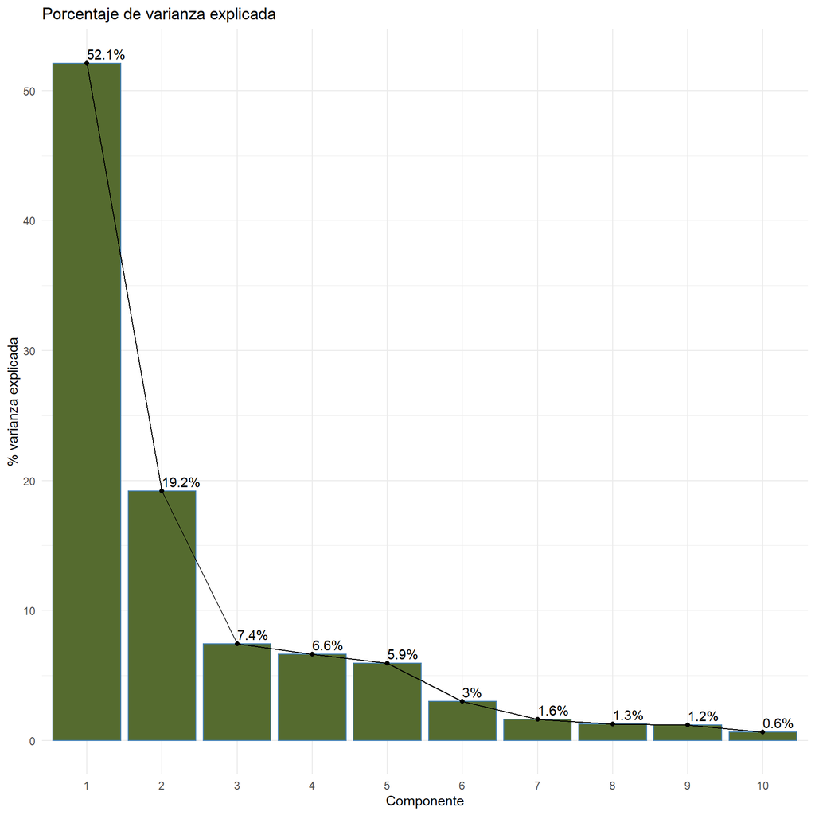

```r
# Visualizamos la varianza explicada
fviz_eig(pca_fit,
         barfill = "darkolivegreen",
         addlabels = TRUE) +
  theme_minimal() +
  labs(x = "Componente",
       y = "% varianza explicada",
       title = "Porcentaje de varianza explicada")
```

> Construye un gráfico para visualizar la varianza explicada acumulada (con una línea horizontal que nos indica el umbral del 95%)

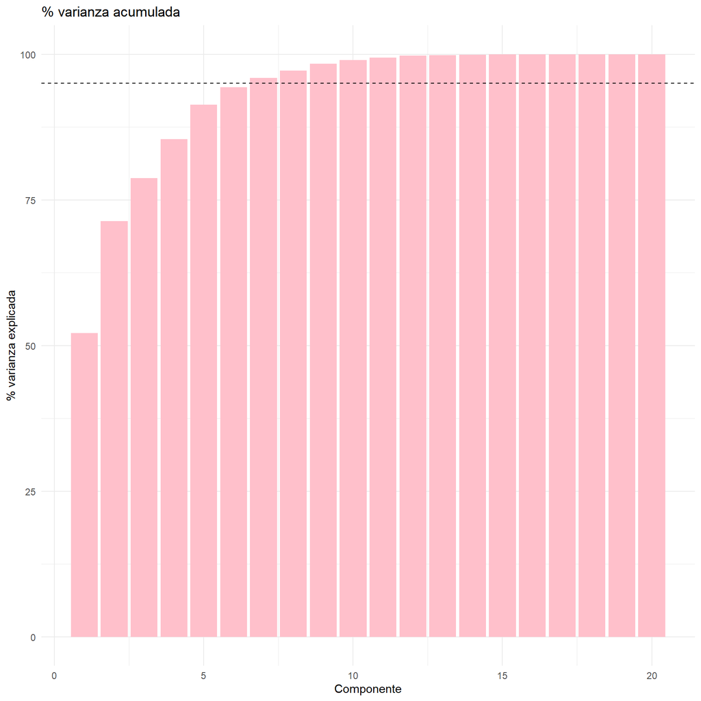

```r
# Calculamos la varianza acumulada
cumvar <- as_tibble(pca_fit$eig)
names(cumvar) <- c("lambda", "var", "cumvar")

# La graficamos
ggplot(cumvar, aes(x = 1:20, y = cumvar)) +
  geom_col(fill = "pink") +
  geom_hline(yintercept = 95,
             linetype = "dashed", color="black") +
  theme_minimal() +
  labs(x = "Componente",
       y = "% varianza explicada",
       title = "% varianza acumulada")
```

> Mostrar los coeficientes (scores) para obtener las componentes principales. ¿Cuál es la expresión para calcular la primera componente en función de las variables originales?

```r
# Calculamos los scores
pca_scores <- as_tibble(pca_fit$ind$coord)
pca_scores # Nuevas coordenadas
```

[output not shown]

> Usando `fviz_pca_var()` visualiza de forma bidimensional como se relacionan las variables originales con las dos componentes que mayor cantidad de varianza capturan. Detalla los resultados. ¿Ves algún grupo de variables? ¿Cuál de las variables es la que está peor explicada?

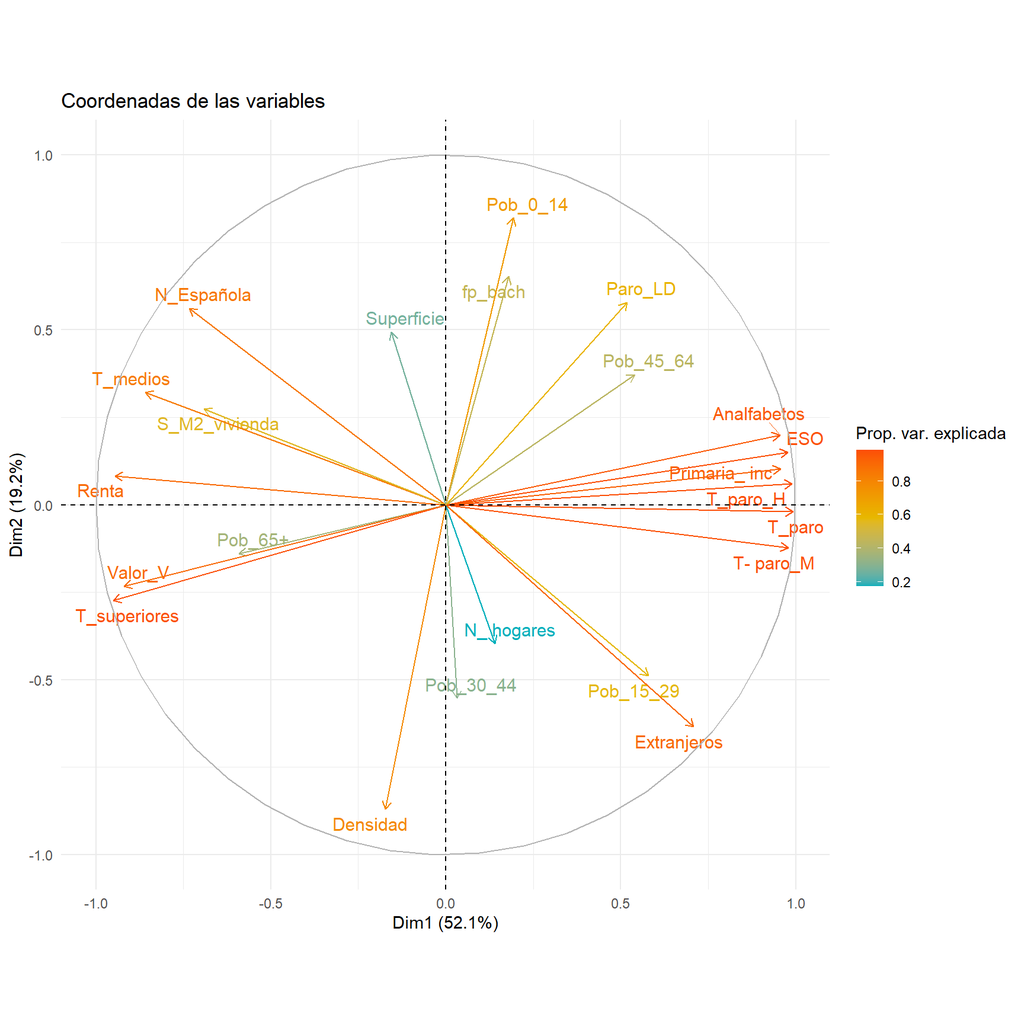

```r
# Visualizamos de forma bidimensional
col <- c("#00AFBB", "#E7B800", "#FC4E07")
fviz_pca_var(pca_fit, col.var = "cos2",
             gradient.cols = col,
             repel = TRUE) +
  theme_minimal() +
  labs(title = "Coordenadas de las variables",
       color = "Prop. var. explicada")
```

Podemos observar un conjunto de variables que se agrupan como pueden ser Analfabetos, ESO, Primaria_inc, T_paro_H, T_paro y T_paro_M, no se aprecian otros grupos de variables tan evidentes. El valor que está peor explicado en mi opinión es N_Hogares ya que apenas le aporta valor la componente 1, la cual es la más importante y a su vez tiene un porcentaje de Prop.var.explicada muchísimo menor al resto de las variables.

> Haciendo uso `fviz_cos2()`, visualiza el porcentaje de la varianza de las variables que es explicada por las tres primeras componentes

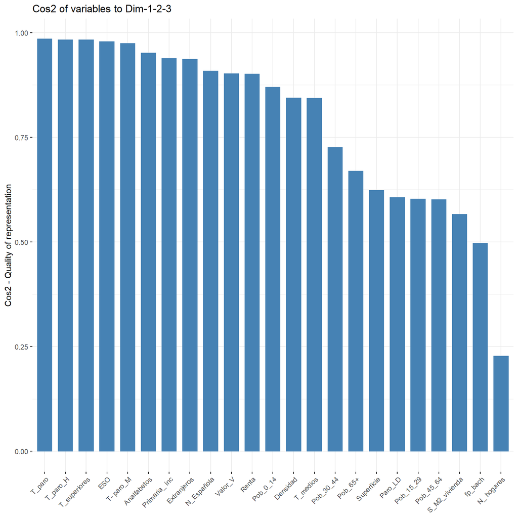

```r
# Utilizamos la fórmula fviz_cos2 para visualizar el porcentaje de la varianza de las variables
fviz_cos2(pca_fit, choice = "var",
          axes = 1:3)
```

> Con `fviz_pca_biplot()` visualiza en las dos dimensiones que más varianza capturan los clústers de observaciones con las elipses definidas por las matrices de covarianza de cada uno de los grupos (añadiendo el partido más votado en cada distrito en color). Teniendo en cuenta el anterior biplot, comentar las características socioeconómicas de algunos grupos de distritos

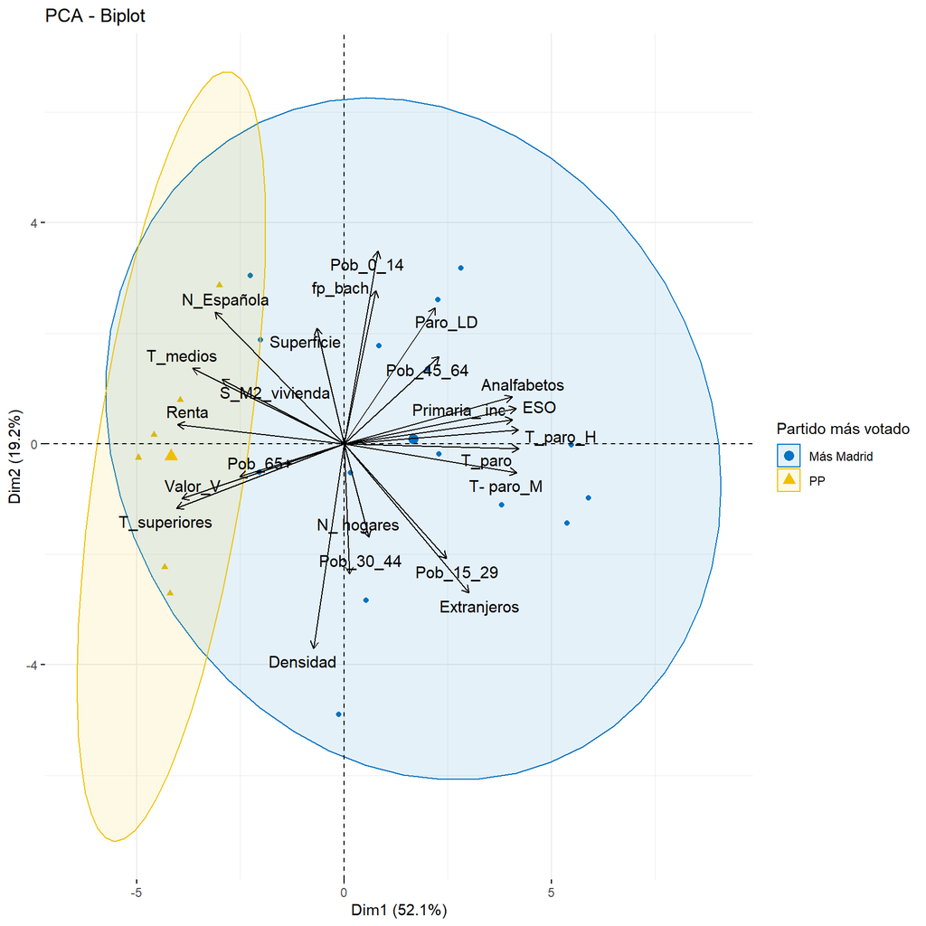

```r
# Con `fviz_pca_biplot()` visualizamos en las dos dimensiones que más varianza capturan los clústers
fviz_pca_biplot(pca_fit,
                col.ind = distritos$Partido,
                palette = "jco",
                addEllipses = TRUE,
                label = "var",
                col.var = "black",
                repel = TRUE,
                legend.title = "Partido más votado")
```

> ¿Qué valor tiene el distrito de Salamanca en la Componente 1? ¿Y Villaverde? ¿Qué distrito tiene un valor más alto de la Componente 4?

```r
# Completa el código
receta <-
  recipe(Distrito ~ ., data = distritos) %>%
  # Imputamos por la media las numéricas, por la moda las cuali
  step_impute_mean(all_numeric_predictors()) %>%
  step_impute_mode(all_nominal_predictors()) %>%
  # Estandarizamos
  step_normalize(all_numeric_predictors()) %>%
  # Filtro cero varianza
  step_zv(all_numeric_predictors())

receta <-
  receta %>%
  step_pca(all_numeric_predictors(), num_comp = 4,
           prefix = "PC")

data_pc <- bake(receta %>% prep(), new_data = NULL)
data_pc
```

```
# A tibble: 21 × 6
   Partido    Distrito               PC1    PC2     PC3    PC4
   <fct>      <fct>                <dbl>  <dbl>   <dbl>  <dbl>
 1 Más Madrid CENTRO               0.128  4.78   1.76   -2.12
 2 Más Madrid ARGANZUELA           1.99   0.503 -0.371  -0.993
 3 PP         RETIRO               4.48  -0.161 -1.36    0.104
 4 PP         SALAMANCA            4.22   2.18  -0.516   0.154
 5 PP         CHAMARTÍN            4.85   0.242 -0.191   0.325
 6 Más Madrid TETUÁN              -0.520  2.76   0.588  -0.414
 7 PP         CHAMBERÍ             4.09   2.64  -0.306   0.474
 8 PP         FUENCARRAL-EL PARDO  2.93  -2.80   3.02    2.85
 9 PP         MONCLOA-ARAVACA      3.86  -0.777 -0.0504  0.501
10 Más Madrid LATINA              -2.23   0.181 -0.676   1.65
# … with 11 more rows
```

- **¿Qué valor tiene el distrito de Salamanca en la Componente 1?** 4.22
- **¿Y Villaverde?** -5.35
- **¿Qué distrito tiene un valor más alto de la Componente 4?** Fuencarral-El Pardo 2.84

# Ejercicio 5

> Haz uso de tidymodels para calcular las componentes y las 5 componentes que más varianza capturan en una matriz de gráficas (la diagonal la propia densidad de las componentes, fuera de la diagonal los datos proyectados en la componente (i,j)). Codifica el color como el partido más votado. Al margen de la varianza explicada, ¿qué par de componentes podrían servirnos mejor para «clasificar» nuestros barrios según el partido más votado?

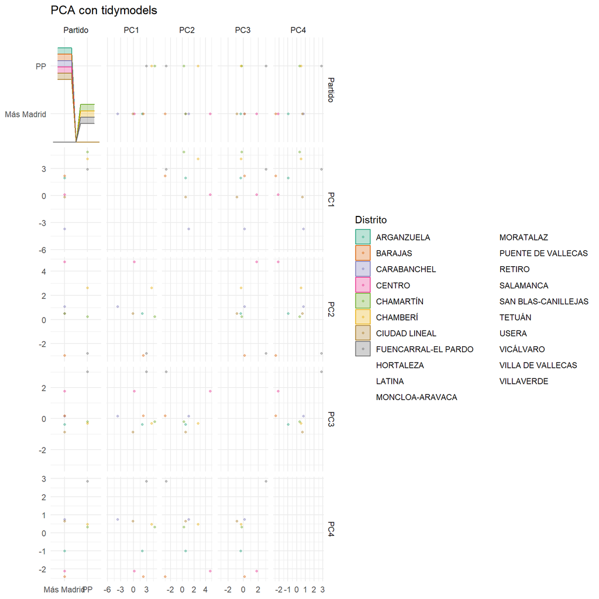

```r
# Usamos tidymodels para calcular las componentes y las 5 componentes que más varianza capturan en una matriz de gráficas
ggplot(data_pc,
       aes(x = .panel_x, y = .panel_y,
           color = Distrito, fill = Distrito)) +
  geom_point(alpha = 0.4, size = 0.9) +
  ggforce::geom_autodensity(alpha = 0.3) +
  ggforce::facet_matrix(vars(-Distrito), layer.diag = 2) +
  scale_color_brewer(palette = "Dark2") +
  scale_fill_brewer(palette = "Dark2") +
  theme_minimal() +
  labs(title = "PCA con tidymodels")
```